# LME Analysis of PNs

Antoin Rodgers

18.05.2022

## L targets

### Analysis of L timing

- intercepts only model
- trim: +/- residual sd > 3

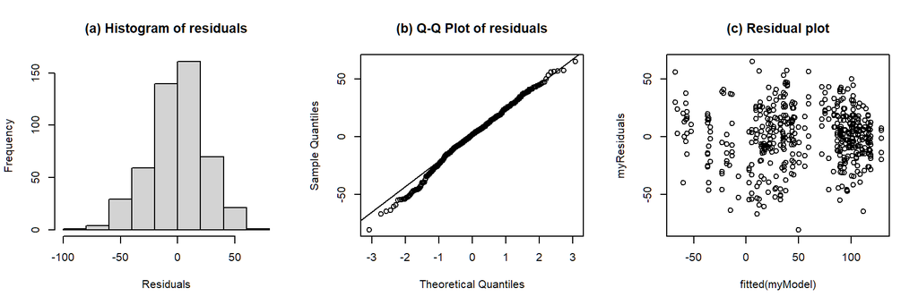

```
## Formula:  l_t ~ acc_phon + ana_syls + foot_syls + wrd_end_syl + pn_new_word + gender + (1 | speaker) + (1 | pn_str_syl) + (1 | nuc_pre_text)
##
## Linear mixed model fit by REML. t-tests use Satterthwaite's method [
## lmerModLmerTest]
## Formula: l_t_equation
##    Data: pn_l_t.trimmed
## Control:
## lmerControl(optimizer = optimizer, calc.derivs = FALSE, optCtrl = list(method = "nlminb",
##     starttests = FALSE, kkt = FALSE))
##
## REML criterion at convergence: 4479.4
##
## Scaled residuals:
##     Min      1Q  Median      3Q     Max
## -3.2428 -0.5630  0.0651  0.6318  2.6099
##
## Random effects:
##  Groups       Name        Variance Std.Dev.
##  nuc_pre_text (Intercept) 1024.0   32.00
##  speaker      (Intercept)  110.8   10.53
##  pn_str_syl   (Intercept)  931.2   30.52
##  Residual                  619.4   24.89
## Number of obs: 486, groups:  nuc_pre_text, 12; speaker, 11; pn_str_syl, 8
##
## Fixed effects:
##                 Estimate Std. Error      df t value Pr(>|t|)
## (Intercept)       82.342     40.607   4.075   2.028  0.11120
## acc_phonL*        24.835      9.599 468.890   2.587  0.00998 **
## ana_syls1        -52.504     48.503   4.843  -1.082  0.32997
## ana_syls2        -23.045     62.254   4.258  -0.370  0.72893
## ana_syls3        -12.484     62.271   4.263  -0.200  0.85031
## foot_syls2       -10.580     40.799   2.847  -0.259  0.81301
## foot_syls3        18.454     42.485   2.697   0.434  0.69639
## foot_syls4        57.970     48.216   3.890   1.202  0.29729
## wrd_end_syl2     -32.022     20.877  25.780  -1.534  0.13726
## wrd_end_syl3     -37.628     23.760  40.615  -1.584  0.12102
## pn_new_wordTRUE    4.307     50.410   4.889   0.085  0.93531
## genderM          -70.861      6.955   9.848 -10.188 1.51e-06 ***
## ---
## Signif. codes:  0 '***' 0.001 '**' 0.01 '*' 0.05 '.' 0.1 ' ' 1
```

[output cut: 41 more lines]

```
##
##             Eliminated Sum Sq Mean Sq NumDF  DenDF  F value    Pr(>F)
## pn_new_word          1      5       5     1   4.89   0.0073   0.93531
## foot_syls            2   1932     644     3   3.84   1.0387   0.46886
## ana_syls             3   3889    1296     3   2.00   2.0632   0.34295
## wrd_end_syl          4   4609    2304     2   6.99   3.6455   0.08233 .
## acc_phon             0   4010    4010     1 472.69   6.3934   0.01178 *
## gender               0  63859   63859     1   9.80 101.8020 1.724e-06 ***
## ---
## Signif. codes:  0 '***' 0.001 '**' 0.01 '*' 0.05 '.' 0.1 ' ' 1
##
## Model found:
## l_t ~ acc_phon + gender + (1 | speaker) + (1 | pn_str_syl) + (1 | nuc_pre_text)
##
## isSingular(my_model, tol = 1e-05 ) --> FALSE
```

ANOVA of model: l_t ~ acc_phon + ana_syls + foot_syls + wrd_end_syl + pn_new_word + gender + (1 | speaker) + (1 | pn_str_syl) + (1 | nuc_pre_text)

| term | sumsq | meansq | NumDF | DenDF | F value | p.value | p.adj (BH) | signif. |
| --- | --- | --- | --- | --- | --- | --- | --- | --- |
| acc_phon | 4146 | 4146 | 1 | 468.89 | 6.69 | .010 | .033 | p<.05 |
| ana_syls | 3973 | 1324 | 3 | 4.97 | 2.14 | .215 | .455 |  |
| foot_syls | 1762 | 587.48 | 3 | 3.15 | 0.95 | .513 | .711 |  |
| wrd_end_syl | 1612 | 805.81 | 2 | 53.17 | 1.3 | .281 | .528 |  |
| pn_new_word | 4.52 | 4.52 | 1 | 4.89 | 7.0e-03 | .935 | .966 |  |
| gender | 64293 | 64293 | 1 | 9.85 | 103.79 | <.001 | <.001 | p<.001 |

[figure not shown]

Conditional and marginal R<sup>2</sup> of model

| R2_conditional | R2_marginal |
| --- | --- |
| 0.87 | 0.44 |

$acc_phon

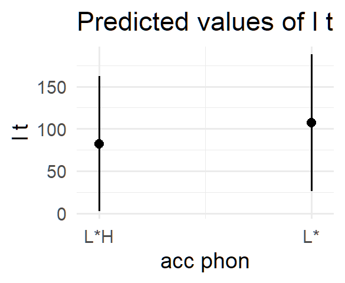

$ana_syls

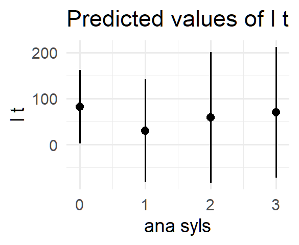

$foot_syls

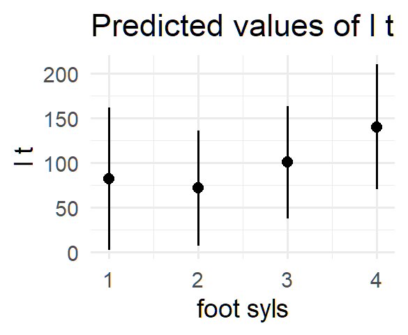

$wrd_end_syl

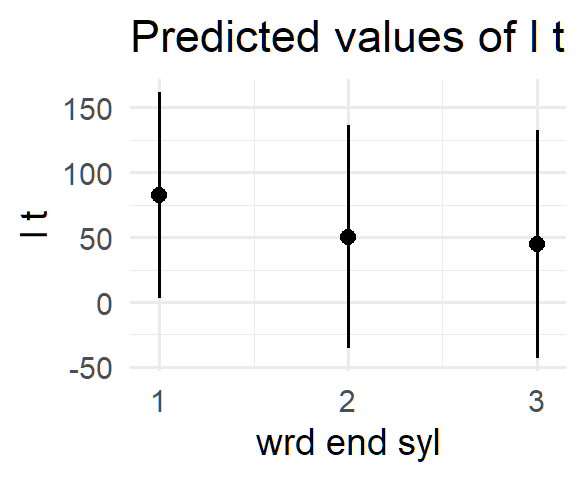

$pn_new_word

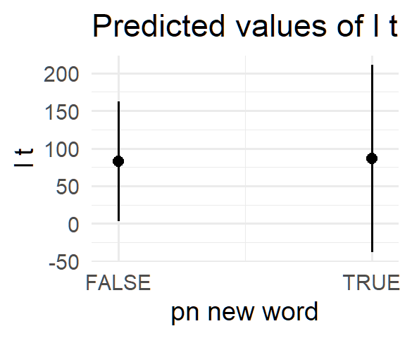

$gender

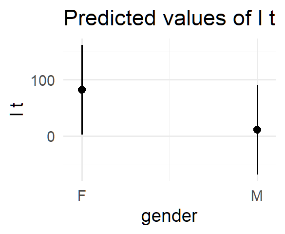

summary of model: l_t ~ acc_phon + ana_syls + foot_syls + wrd_end_syl + pn_new_word + gender + (1 | speaker) + (1 | pn_str_syl) + (1 | nuc_pre_text)

| term | estimate | conf.low | conf.high | std.error | t.value | df | p.value |
| --- | --- | --- | --- | --- | --- | --- | --- |
| (Intercept) | 82.342 | -29.583611 | 194.26837 | 40.607 | 2.028 | 4.08 | 0.1112 |
| acc_phonL* | 24.835 | 5.972345 | 43.69692 | 9.599 | 2.587 | 468.89 | 0.01 |
| ana_syls1 | -52.504 | -178.414584 | 73.40715 | 48.503 | -1.082 | 4.84 | 0.33 |
| ana_syls2 | -23.045 | -191.837605 | 145.74685 | 62.254 | -0.370 | 4.26 | 0.7289 |
| ana_syls3 | -12.484 | -181.251427 | 156.28295 | 62.271 | -0.200 | 4.26 | 0.8503 |
| foot_syls2 | -10.580 | -144.455067 | 123.29604 | 40.799 | -0.259 | 2.85 | 0.813 |
| foot_syls3 | 18.454 | -125.752360 | 162.66014 | 42.485 | 0.434 | 2.70 | 0.6964 |
| foot_syls4 | 57.970 | -77.411624 | 193.35132 | 48.216 | 1.202 | 3.89 | 0.2973 |
| wrd_end_syl2 | -32.022 | -74.954068 | 10.90977 | 20.877 | -1.534 | 25.78 | 0.1373 |
| wrd_end_syl3 | -37.628 | -85.625137 | 10.36971 | 23.760 | -1.584 | 40.61 | 0.121 |
| pn_new_wordTRUE | 4.307 | -126.170136 | 134.78327 | 50.410 | 0.085 | 4.89 | 0.9353 |
| genderM | -70.861 | -86.390812 | -55.33084 | 6.955 | -10.188 | 9.85 | 1.5e-06 |

b0 for l_t ~ acc_phon + ana_syls + foot_syls + wrd_end_syl + pn_new_word + gender + (1 | speaker) + (1 | pn_str_syl) + (1 | nuc_pre_text)

| intercept | estimate | conf.low | conf.high | std.error | t.value | df | p.value |
| --- | --- | --- | --- | --- | --- | --- | --- |
| ana_syls0 | 82.3 | -29.6 | 194.3 | 40.61 | 2.03 | 4.08 | 0.111 |
| ana_syls1 | 29.8 | -123.3 | 183 | 57.02 | 0.52 | 4.37 | 0.626 |
| ana_syls2 | 59.3 | -145.6 | 264.2 | 72.35 | 0.82 | 3.81 | 0.461 |
| ana_syls3 | 69.9 | -135 | 274.7 | 72.36 | 0.97 | 3.81 | 0.392 |
| foot_syls1 | 82.3 | -29.6 | 194.3 | 40.61 | 2.03 | 4.08 | 0.111 |
| foot_syls2 | 71.8 | -12.9 | 156.4 | 32.89 | 2.18 | 4.98 | 0.081 |
| foot_syls3 | 100.8 | 19.9 | 181.7 | 32.08 | 3.14 | 5.33 | 0.023 |
| foot_syls4 | 140.3 | 56.7 | 223.9 | 35.79 | 3.92 | 7.45 | 0.005 |
| wrd_end_syl1 | 82.3 | -29.6 | 194.3 | 40.61 | 2.03 | 4.08 | 0.111 |
| wrd_end_syl2 | 50.3 | -65.8 | 166.5 | 43.80 | 1.15 | 4.54 | 0.308 |
| wrd_end_syl3 | 44.7 | -72.2 | 161.7 | 44.68 | 1.00 | 4.72 | 0.365 |

b1 for l_t ~ acc_phon + ana_syls + foot_syls + wrd_end_syl + pn_new_word + gender + (1 | speaker) + (1 | pn_str_syl) + (1 | nuc_pre_text)

| intercept | slope | estimate | conf.low | conf.high | std.error | t.value | df | p.value |
| --- | --- | --- | --- | --- | --- | --- | --- | --- |
| ana_syls0 | ana_syls1 | -52.5 | -178.4 | 73.4 | 48.500 | -1.080 | 4.84 | 0.33 |
| ana_syls0 | ana_syls2 | -23 | -191.8 | 145.7 | 62.250 | -0.370 | 4.26 | 0.729 |
| ana_syls0 | ana_syls3 | -12.5 | -181.3 | 156.3 | 62.270 | -0.200 | 4.26 | 0.85 |
| ana_syls1 | ana_syls2 | 29.5 | -110.1 | 169 | 41.540 | 0.710 | 2.74 | 0.534 |
| ana_syls1 | ana_syls3 | 40 | -99.5 | 179.5 | 41.550 | 0.960 | 2.74 | 0.412 |
| ana_syls2 | ana_syls3 | 10.6 | 0.912 | 20.2 | 4.910 | 2.150 | 457.18 | 0.032 |
| foot_syls1 | foot_syls2 | -10.6 | -144.5 | 123.3 | 40.800 | -0.260 | 2.85 | 0.813 |
| foot_syls1 | foot_syls3 | 18.4 | -125.8 | 162.7 | 42.490 | 0.430 | 2.70 | 0.696 |
| foot_syls1 | foot_syls4 | 58 | -77.4 | 193.4 | 48.220 | 1.200 | 3.89 | 0.297 |
| foot_syls2 | foot_syls3 | 29 | -81.4 | 139.5 | 36.380 | 0.800 | 3.28 | 0.479 |
| foot_syls2 | foot_syls4 | 68.6 | -37.8 | 174.9 | 41.300 | 1.660 | 4.97 | 0.158 |
| foot_syls3 | foot_syls4 | 39.5 | -65.8 | 144.8 | 35.850 | 1.100 | 3.51 | 0.34 |
| wrd_end_syl1 | wrd_end_syl2 | -32 | -75 | 10.9 | 20.880 | -1.530 | 25.78 | 0.137 |
| wrd_end_syl1 | wrd_end_syl3 | -37.6 | -85.6 | 10.4 | 23.760 | -1.580 | 40.61 | 0.121 |
| wrd_end_syl2 | wrd_end_syl3 | -5.61 | -28.2 | 17 | 11.510 | -0.490 | 397.73 | 0.626 |
| intercept | acc_phonL* | 24.8 | 5.972 | 43.7 | 9.599 | 2.587 | 468.89 | 0.01 |
| intercept | pn_new_wordTRUE | 4.307 | -126.2 | 134.8 | 50.410 | 0.085 | 4.89 | 0.935 |
| intercept | genderM | -70.9 | -86.4 | -55.3 | 6.955 | -10.188 | 9.85 | 1.5e-06 |

### Analysis of L F0

After initial full model, step() suggests: `l_f0 ~ ana_syls + pn_new_word + (1 | speaker)` Model works with single random intercept but with all fixed factors.

- model needs trimming (|sd| residuals > 3.5)

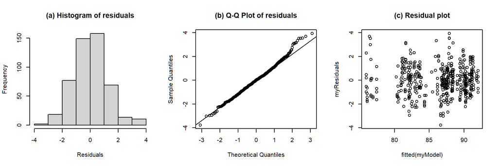

```
## Formula:  l_f0 ~ acc_phon + ana_syls + foot_syls + wrd_end_syl + pn_new_word + (1 | speaker)
##
## Linear mixed model fit by REML. t-tests use Satterthwaite's method [
## lmerModLmerTest]
## Formula: l_f0_equation
##    Data: pn_l_f0.trimmed
## Control:
## lmerControl(optimizer = optimizer, calc.derivs = FALSE, optCtrl = list(method = "nlminb",
##     starttests = FALSE, kkt = FALSE))
##
## REML criterion at convergence: 1679.2
##
## Scaled residuals:
##     Min      1Q  Median      3Q     Max
## -3.0688 -0.6423  0.0099  0.5858  3.2007
##
## Random effects:
##  Groups   Name        Variance Std.Dev.
##  speaker  (Intercept) 19.838   4.454
##  Residual              1.504   1.227
## Number of obs: 496, groups:  speaker, 11
##
## Fixed effects:
##                  Estimate Std. Error        df t value Pr(>|t|)
## (Intercept)      85.96300    1.35904  10.44202  63.253 7.74e-15 ***
## acc_phonL*       -0.17536    0.45437 475.16858  -0.386    0.700
## ana_syls1         0.91173    0.19131 475.02011   4.766 2.51e-06 ***
## ana_syls2         0.21623    0.30249 475.02916   0.715    0.475
## ana_syls3         0.07360    0.30376 475.02967   0.242    0.809
## foot_syls2       -0.10292    0.24481 475.03863  -0.420    0.674
## foot_syls3       -0.11712    0.26678 475.05542  -0.439    0.661
## foot_syls4       -0.01257    0.28864 475.04098  -0.044    0.965
## wrd_end_syl2     -0.20437    0.19243 475.04626  -1.062    0.289
## wrd_end_syl3     -0.43279    0.30492 475.05200  -1.419    0.156
## pn_new_wordTRUE  -0.75729    0.26181 475.02749  -2.892    0.004 **
## ---
## Signif. codes:  0 '***' 0.001 '**' 0.01 '*' 0.05 '.' 0.1 ' ' 1
##
## Correlation of Fixed Effects:
##             (Intr) acc_L* an_sy1 an_sy2 an_sy3 ft_sy2 ft_sy3 ft_sy4 wrd__2
```

[output cut: 33 more lines]

```
## Degrees of freedom method: Satterthwaite
##
##             Eliminated Sum Sq Mean Sq NumDF  DenDF F value    Pr(>F)
## foot_syls            1  0.611  0.2038     3 475.04  0.1354 0.9388832
## acc_phon             2  0.156  0.1560     1 478.17  0.1043 0.7469240
## wrd_end_syl          3  4.932  2.4660     2 479.07  1.6511 0.1929251
## ana_syls             0 84.909 28.3030     3 481.04 18.9008 1.328e-11 ***
## pn_new_word          0 18.448 18.4478     1 481.06 12.3195 0.0004904 ***
## ---
## Signif. codes:  0 '***' 0.001 '**' 0.01 '*' 0.05 '.' 0.1 ' ' 1
##
## Model found:
## l_f0 ~ ana_syls + pn_new_word + (1 | speaker)
##
## isSingular(my_model, tol = 1e-05 ) --> FALSE
```

ANOVA of model: l_f0 ~ acc_phon + ana_syls + foot_syls + wrd_end_syl + pn_new_word + (1 | speaker)

| term | sumsq | meansq | NumDF | DenDF | F value | p.value | p.adj (BH) | signif. |
| --- | --- | --- | --- | --- | --- | --- | --- | --- |
| acc_phon | 0.22 | 0.22 | 1 | 475.17 | 0.15 | .700 | .869 |  |
| ana_syls | 56.69 | 18.9 | 3 | 475.02 | 12.56 | <.001 | <.001 | p<.001 |
| foot_syls | 0.61 | 0.2 | 3 | 475.04 | 0.14 | .939 | .966 |  |
| wrd_end_syl | 3.11 | 1.55 | 2 | 475.06 | 1.03 | .356 | .558 |  |
| pn_new_word | 12.59 | 12.59 | 1 | 475.03 | 8.37 | .004 | .014 | p<.05 |

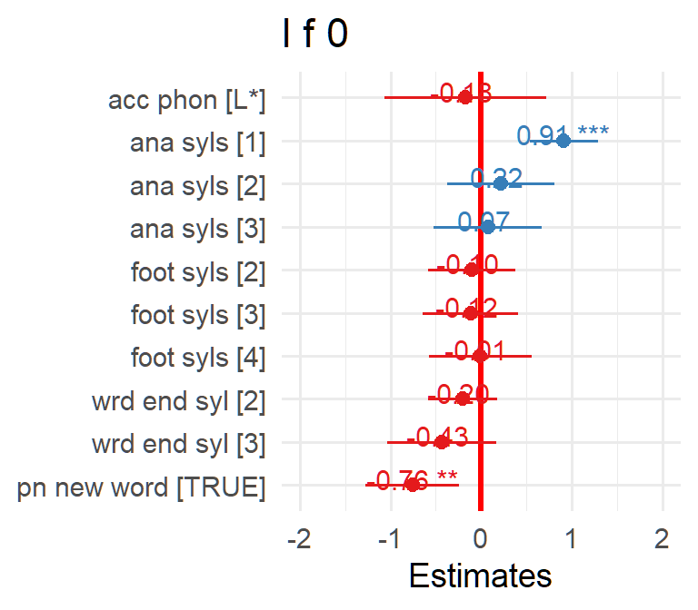

Conditional and marginal R<sup>2</sup> of model

| R2_conditional | R2_marginal |
| --- | --- |
| 0.93 | 0.01 |

$acc_phon

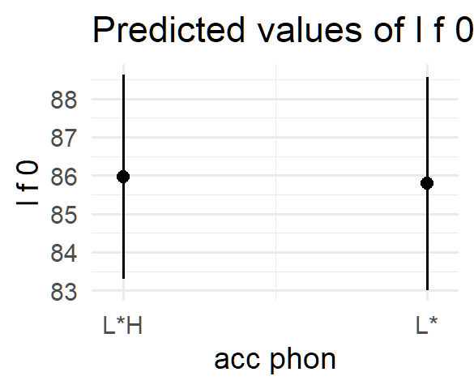

$ana_syls

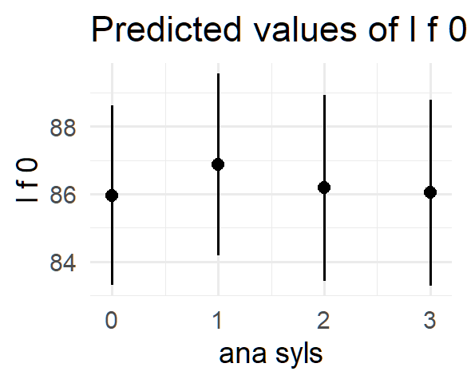

$foot_syls

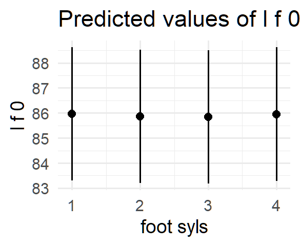

$wrd_end_syl

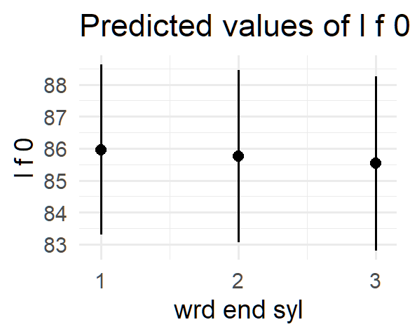

$pn_new_word

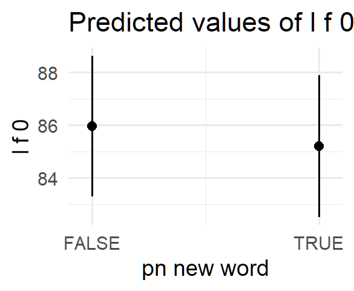

summary of model: l_f0 ~ acc_phon + ana_syls + foot_syls + wrd_end_syl + pn_new_word + (1 | speaker)

| term | estimate | conf.low | conf.high | std.error | t.value | df | p.value |
| --- | --- | --- | --- | --- | --- | --- | --- |
| (Intercept) | 85.963 | 82.9521565 | 88.9738468 | 1.359 | 63.253 | 10.44 | 7.7e-15 |
| acc_phonL* | -0.175 | -1.0681762 | 0.7174554 | 0.454 | -0.386 | 475.17 | 0.6997 |
| ana_syls1 | 0.912 | 0.5358064 | 1.2876439 | 0.191 | 4.766 | 475.02 | 2.5e-06 |
| ana_syls2 | 0.216 | -0.3781550 | 0.8106086 | 0.302 | 0.715 | 475.03 | 0.4751 |
| ana_syls3 | 0.074 | -0.5232849 | 0.6704881 | 0.304 | 0.242 | 475.03 | 0.8087 |
| foot_syls2 | -0.103 | -0.5839760 | 0.3781311 | 0.245 | -0.420 | 475.04 | 0.6744 |
| foot_syls3 | -0.117 | -0.6413321 | 0.4070935 | 0.267 | -0.439 | 475.06 | 0.6609 |
| foot_syls4 | -0.013 | -0.5797483 | 0.5546094 | 0.289 | -0.044 | 475.04 | 0.9653 |
| wrd_end_syl2 | -0.204 | -0.5824835 | 0.1737493 | 0.192 | -1.062 | 475.05 | 0.2888 |
| wrd_end_syl3 | -0.433 | -1.0319551 | 0.1663676 | 0.305 | -1.419 | 475.05 | 0.1564 |
| pn_new_wordTRUE | -0.757 | -1.2717456 | -0.2428317 | 0.262 | -2.892 | 475.03 | 0.004 |

b0 for l_f0 ~ acc_phon + ana_syls + foot_syls + wrd_end_syl + pn_new_word + (1 | speaker)

| intercept | estimate | conf.low | conf.high | std.error | t.value | df | p.value |
| --- | --- | --- | --- | --- | --- | --- | --- |
| ana_syls0 | 86 | 83 | 89 | 1.36 | 63.25 | 10.44 | 7.7e-15 |
| ana_syls1 | 86.9 | 83.8 | 89.9 | 1.37 | 63.30 | 10.86 | 2.7e-15 |
| ana_syls2 | 86.2 | 83.1 | 89.2 | 1.40 | 61.59 | 11.73 | 4.3e-16 |
| ana_syls3 | 86 | 83 | 89.1 | 1.40 | 61.48 | 11.74 | 4.3e-16 |
| foot_syls1 | 86 | 83 | 89 | 1.36 | 63.25 | 10.44 | 7.7e-15 |
| foot_syls2 | 85.9 | 82.9 | 88.9 | 1.36 | 63.23 | 10.41 | 8.5e-15 |
| foot_syls3 | 85.8 | 82.8 | 88.9 | 1.35 | 63.36 | 10.31 | 1.1e-14 |
| foot_syls4 | 86 | 82.9 | 89 | 1.37 | 62.96 | 10.63 | 5.0e-15 |
| wrd_end_syl1 | 86 | 83 | 89 | 1.36 | 63.25 | 10.44 | 7.7e-15 |
| wrd_end_syl2 | 85.8 | 82.7 | 88.8 | 1.37 | 62.51 | 10.84 | 3.2e-15 |
| wrd_end_syl3 | 85.5 | 82.5 | 88.6 | 1.39 | 61.64 | 11.34 | 1.1e-15 |

b1 for l_f0 ~ acc_phon + ana_syls + foot_syls + wrd_end_syl + pn_new_word + (1 | speaker)

| intercept | slope | estimate | conf.low | conf.high | std.error | t.value | df | p.value |
| --- | --- | --- | --- | --- | --- | --- | --- | --- |
| ana_syls0 | ana_syls1 | 0.91 | 0.536 | 1.288 | 0.190 | 4.770 | 475.02 | 2.5e-06 |
| ana_syls0 | ana_syls2 | 0.22 | -0.378 | 0.811 | 0.300 | 0.710 | 475.03 | 0.475 |
| ana_syls0 | ana_syls3 | 0.07 | -0.523 | 0.67 | 0.300 | 0.240 | 475.03 | 0.809 |
| ana_syls1 | ana_syls2 | -0.7 | -1.155 | -0.236 | 0.230 | -2.970 | 475.03 | 0.003 |
| ana_syls1 | ana_syls3 | -0.84 | -1.301 | -0.376 | 0.240 | -3.560 | 475.03 | 4.1e-04 |
| ana_syls2 | ana_syls3 | -0.14 | -0.618 | 0.332 | 0.240 | -0.590 | 475.01 | 0.556 |
| foot_syls1 | foot_syls2 | -0.1 | -0.584 | 0.378 | 0.240 | -0.420 | 475.04 | 0.674 |
| foot_syls1 | foot_syls3 | -0.12 | -0.641 | 0.407 | 0.270 | -0.440 | 475.06 | 0.661 |
| foot_syls1 | foot_syls4 | -0.01 | -0.58 | 0.555 | 0.290 | -0.040 | 475.04 | 0.965 |
| foot_syls2 | foot_syls3 | -0.01 | -0.529 | 0.5 | 0.260 | -0.050 | 475.05 | 0.957 |
| foot_syls2 | foot_syls4 | 0.09 | -0.48 | 0.66 | 0.290 | 0.310 | 475.04 | 0.756 |
| foot_syls3 | foot_syls4 | 0.1 | -0.327 | 0.536 | 0.220 | 0.480 | 475.02 | 0.634 |
| wrd_end_syl1 | wrd_end_syl2 | -0.2 | -0.582 | 0.174 | 0.190 | -1.060 | 475.05 | 0.289 |
| wrd_end_syl1 | wrd_end_syl3 | -0.43 | -1.032 | 0.166 | 0.300 | -1.420 | 475.05 | 0.156 |
| wrd_end_syl2 | wrd_end_syl3 | -0.23 | -0.698 | 0.241 | 0.240 | -0.960 | 475.08 | 0.34 |
| intercept | acc_phonL* | -0.175 | -1.068 | 0.717 | 0.454 | -0.386 | 475.17 | 0.7 |
| intercept | pn_new_wordTRUE | -0.757 | -1.272 | -0.243 | 0.262 | -2.892 | 475.03 | 0.004 |

## H targets

### Analysis of H timing

first test, step() found: `h_t ~ acc_phon + ana_syls + gender + (1 | speaker) + (1 | nuc_pre_text)`

- model needs trimming (residuals +/- 2.75 s.d.)

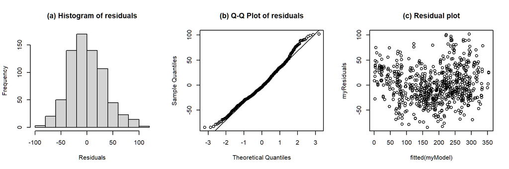

```
## Formula:  h_t ~ acc_phon + ana_syls + foot_syls + wrd_end_syl + pn_new_word + gender + (1 | speaker) + (1 | ana_text) + (1 | nuc_pre_text) + (1 | speech_rate)
##
## Linear mixed model fit by REML. t-tests use Satterthwaite's method [
## lmerModLmerTest]
## Formula: h_t_equation
##    Data: pn_h_t.trimmed
## Control:
## lmerControl(optimizer = optimizer, calc.derivs = FALSE, optCtrl = list(method = "nlminb",
##     starttests = FALSE, kkt = FALSE))
##
## REML criterion at convergence: 7155.2
##
## Scaled residuals:
##     Min      1Q  Median      3Q     Max
## -2.3383 -0.6634 -0.1155  0.6290  2.8339
##
## Random effects:
##  Groups       Name        Variance Std.Dev.
##  speech_rate  (Intercept)   81.99   9.055
##  nuc_pre_text (Intercept)  735.48  27.120
##  speaker      (Intercept)  486.07  22.047
##  ana_text     (Intercept)   88.53   9.409
##  Residual                 1293.80  35.969
## Number of obs: 714, groups:
## speech_rate, 591; nuc_pre_text, 12; speaker, 11; ana_text, 7
##
## Fixed effects:
##                 Estimate Std. Error      df t value Pr(>|t|)
## (Intercept)      232.318     30.698   5.823   7.568 0.000319 ***
## acc_phon>H*      -36.682      6.016 686.593  -6.097  1.8e-09 ***
## acc_phonH*       -74.722      4.749 694.137 -15.734  < 2e-16 ***
## ana_syls1        -35.662     30.662   4.389  -1.163 0.304121
## ana_syls2         26.891     46.529   4.726   0.578 0.589744
## ana_syls3         38.247     46.556   4.735   0.822 0.450710
## foot_syls2        23.846     31.926   4.340   0.747 0.493555
## foot_syls3        59.545     35.682   4.685   1.669 0.159961
## foot_syls4        97.636     39.005   5.584   2.503 0.049263 *
## wrd_end_syl2     -39.543     22.332  10.298  -1.771 0.106159
## wrd_end_syl3     -25.425     27.128  17.004  -0.937 0.361764
## pn_new_wordTRUE  -36.363     31.395   4.972  -1.158 0.299353
```

[output cut: 19 more lines]

```
##
##             Eliminated Sum Sq Mean Sq NumDF  DenDF  F value    Pr(>F)
## pn_new_word          1   2001    2001     1   5.14   1.4506 0.2809093
## wrd_end_syl          2   5420    2710     2  25.40   1.9646 0.1609529
## foot_syls            3   9782    3261     3   6.87   2.3544 0.1597383
## acc_phon             0 351735  175867     2 702.75 126.9798 < 2.2e-16 ***
## ana_syls             0 133923   44641     3  24.92  32.2317 9.751e-09 ***
## gender               0  39316   39316     1   9.11  28.3869 0.0004569 ***
## ---
## Signif. codes:  0 '***' 0.001 '**' 0.01 '*' 0.05 '.' 0.1 ' ' 1
##
## Model found:
## h_t ~ acc_phon + ana_syls + gender + (1 | speaker) + (1 | nuc_pre_text)
##
## isSingular(my_model, tol = 1e-05 ) --> FALSE
```

ANOVA of model: h_t ~ acc_phon + ana_syls + foot_syls + wrd_end_syl + pn_new_word + gender + (1 | speaker) + (1 | ana_text) + (1 | nuc_pre_text) + (1 | speech_rate)

| term | sumsq | meansq | NumDF | DenDF | F value | p.value | p.adj (BH) | signif. |
| --- | --- | --- | --- | --- | --- | --- | --- | --- |
| acc_phon | 3.2e+05 | 1.6e+05 | 2 | 687.23 | 124.47 | <.001 | <.001 | p<.001 |
| ana_syls | 7626 | 2542 | 3 | 2 | 1.97 | .355 | .557 |  |
| foot_syls | 9285 | 3095 | 3 | 5.09 | 2.39 | .183 | .411 |  |
| wrd_end_syl | 5116 | 2558 | 2 | 19.72 | 1.98 | .165 | .396 |  |
| pn_new_word | 1736 | 1736 | 1 | 4.97 | 1.34 | .299 | .528 |  |
| gender | 36625 | 36625 | 1 | 9.11 | 28.31 | <.001 | .003 | p<.01 |

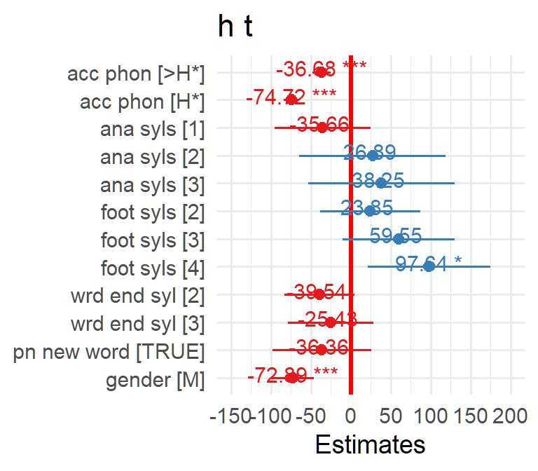

Conditional and marginal R<sup>2</sup> of model

| R2_conditional | R2_marginal |
| --- | --- |
| 0.86 | 0.71 |

$acc_phon

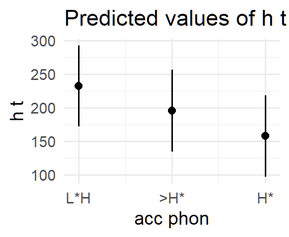

$ana_syls

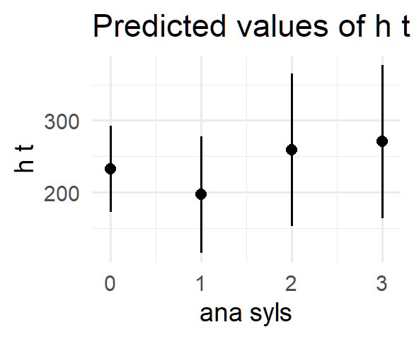

$foot_syls

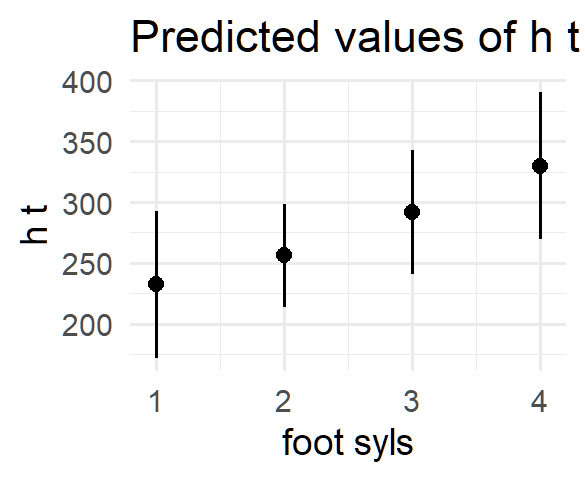

$wrd_end_syl

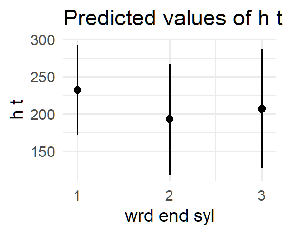

$pn_new_word

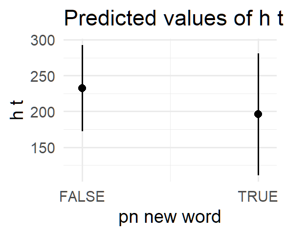

$gender

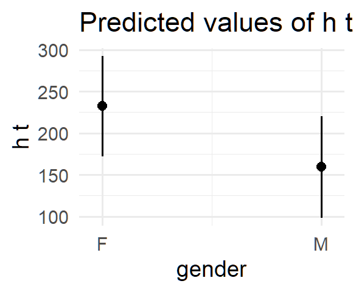

summary of model: h_t ~ acc_phon + ana_syls + foot_syls + wrd_end_syl + pn_new_word + gender + (1 | speaker) + (1 | ana_text) + (1 | nuc_pre_text) + (1 | speech_rate)

| term | estimate | conf.low | conf.high | std.error | t.value | df | p.value |
| --- | --- | --- | --- | --- | --- | --- | --- |
| (Intercept) | 232.318 | 156.6454554 | 307.99064 | 30.698 | 7.568 | 5.82 | 3e-04 |
| acc_phon>H* | -36.682 | -48.4943562 | -24.86876 | 6.016 | -6.097 | 686.59 | 1.8e-09 |
| acc_phonH* | -74.722 | -84.0461908 | -65.39756 | 4.749 | -15.734 | 694.14 | 6.2e-48 |
| ana_syls1 | -35.662 | -117.8994042 | 46.57633 | 30.662 | -1.163 | 4.39 | 0.3041 |
| ana_syls2 | 26.891 | -94.8309640 | 148.61210 | 46.529 | 0.578 | 4.73 | 0.5897 |
| ana_syls3 | 38.247 | -83.4723766 | 159.96696 | 46.556 | 0.822 | 4.73 | 0.4507 |
| foot_syls2 | 23.846 | -62.1186168 | 109.81030 | 31.926 | 0.747 | 4.34 | 0.4936 |
| foot_syls3 | 59.545 | -34.0670153 | 153.15785 | 35.682 | 1.669 | 4.68 | 0.16 |
| foot_syls4 | 97.636 | 0.4447033 | 194.82651 | 39.005 | 2.503 | 5.58 | 0.0493 |
| wrd_end_syl2 | -39.543 | -89.1070543 | 10.02144 | 22.332 | -1.771 | 10.30 | 0.1062 |
| wrd_end_syl3 | -25.425 | -82.6595623 | 31.80906 | 27.128 | -0.937 | 17.00 | 0.3618 |
| pn_new_wordTRUE | -36.363 | -117.2013429 | 44.47571 | 31.395 | -1.158 | 4.97 | 0.2994 |
| genderM | -72.891 | -103.8262028 | -41.95534 | 13.700 | -5.321 | 9.11 | 5e-04 |

b0 for h_t ~ acc_phon + ana_syls + foot_syls + wrd_end_syl + pn_new_word + gender + (1 | speaker) + (1 | ana_text) + (1 | nuc_pre_text) + (1 | speech_rate)

| intercept | estimate | conf.low | conf.high | std.error | t.value | df | p.value |
| --- | --- | --- | --- | --- | --- | --- | --- |
| acc_phonL*H | 232.3 | 156.6 | 308 | 30.70 | 7.57 | 5.82 | 3.2e-04 |
| acc_phon>H* | 195.6 | 120 | 271.3 | 31.15 | 6.28 | 6.18 | 6.8e-04 |
| acc_phonH* | 157.6 | 81.9 | 233.2 | 30.81 | 5.12 | 5.91 | 0.002 |
| ana_syls0 | 232.3 | 156.6 | 308 | 30.70 | 7.57 | 5.82 | 3.2e-04 |
| ana_syls1 | 196.7 | 91.9 | 301.4 | 41.29 | 4.76 | 5.23 | 0.004 |
| ana_syls2 | 259.2 | 121.7 | 396.7 | 54.46 | 4.76 | 5.32 | 0.004 |
| ana_syls3 | 270.6 | 133 | 408.1 | 54.48 | 4.97 | 5.32 | 0.004 |
| foot_syls1 | 232.3 | 156.6 | 308 | 30.70 | 7.57 | 5.82 | 3.2e-04 |
| foot_syls2 | 256.2 | 202.9 | 309.4 | 21.64 | 11.84 | 5.86 | 2.6e-05 |
| foot_syls3 | 291.9 | 230 | 353.7 | 26.08 | 11.19 | 6.90 | 1.1e-05 |
| foot_syls4 | 330 | 260.7 | 399.2 | 30.88 | 10.68 | 9.54 | 1.3e-06 |
| wrd_end_syl1 | 232.3 | 156.6 | 308 | 30.70 | 7.57 | 5.82 | 3.2e-04 |
| wrd_end_syl2 | 192.8 | 103.5 | 282 | 37.84 | 5.09 | 7.09 | 0.001 |
| wrd_end_syl3 | 206.9 | 114.2 | 299.6 | 40.79 | 5.07 | 8.76 | 7.3e-04 |

b1 for h_t ~ acc_phon + ana_syls + foot_syls + wrd_end_syl + pn_new_word + gender + (1 | speaker) + (1 | ana_text) + (1 | nuc_pre_text) + (1 | speech_rate)

| intercept | slope | estimate | conf.low | conf.high | std.error | t.value | df | p.value |
| --- | --- | --- | --- | --- | --- | --- | --- | --- |
| acc_phonL*H | acc_phon>H* | -36.7 | -48.5 | -24.9 | 6.020 | -6.100 | 686.59 | 1.8e-09 |
| acc_phonL*H | acc_phonH* | -74.7 | -84 | -65.4 | 4.750 | -15.730 | 694.14 | 6.2e-48 |
| acc_phon>H* | acc_phonH* | -38 | -50.6 | -25.5 | 6.380 | -5.960 | 673.13 | 4.0e-09 |
| ana_syls0 | ana_syls1 | -35.7 | -117.9 | 46.6 | 30.660 | -1.160 | 4.39 | 0.304 |
| ana_syls0 | ana_syls2 | 26.9 | -94.8 | 148.6 | 46.530 | 0.580 | 4.73 | 0.59 |
| ana_syls0 | ana_syls3 | 38.2 | -83.5 | 160 | 46.560 | 0.820 | 4.73 | 0.451 |
| ana_syls1 | ana_syls2 | 62.5 | -27.7 | 152.8 | 35.000 | 1.790 | 4.95 | 0.135 |
| ana_syls1 | ana_syls3 | 73.9 | -16.3 | 164.1 | 35.040 | 2.110 | 4.97 | 0.089 |
| ana_syls2 | ana_syls3 | 11.4 | -381.7 | 404.4 | 15.070 | 0.750 | 0.77 | 0.617 |
| foot_syls1 | foot_syls2 | 23.9 | -62.1 | 109.8 | 31.930 | 0.750 | 4.34 | 0.494 |
| foot_syls1 | foot_syls3 | 59.5 | -34.1 | 153.2 | 35.680 | 1.670 | 4.68 | 0.16 |
| foot_syls1 | foot_syls4 | 97.6 | 0.445 | 194.8 | 39.000 | 2.500 | 5.58 | 0.049 |
| foot_syls2 | foot_syls3 | 35.7 | -35.8 | 107.2 | 28.340 | 1.260 | 5.32 | 0.26 |
| foot_syls2 | foot_syls4 | 73.8 | -3.51 | 151.1 | 32.450 | 2.270 | 6.75 | 0.058 |
| foot_syls3 | foot_syls4 | 38.1 | -33.2 | 109.4 | 28.130 | 1.350 | 5.25 | 0.231 |
| wrd_end_syl1 | wrd_end_syl2 | -39.5 | -89.1 | 10 | 22.330 | -1.770 | 10.30 | 0.106 |
| wrd_end_syl1 | wrd_end_syl3 | -25.4 | -82.7 | 31.8 | 27.130 | -0.940 | 17.00 | 0.362 |
| wrd_end_syl2 | wrd_end_syl3 | 14.1 | -16.6 | 44.8 | 15.490 | 0.910 | 97.98 | 0.364 |
| intercept | pn_new_wordTRUE | -36.4 | -117.2 | 44.5 | 31.395 | -1.158 | 4.97 | 0.299 |
| intercept | genderM | -72.9 | -103.8 | -42 | 13.700 | -5.321 | 9.11 | 4.6e-04 |

## H timing original data

This is to check the extent to which the previous results re ana_syls are an artefact of the larger dataset. This goes for other results too, but as ana_syls has such odd results, it was worth checking.

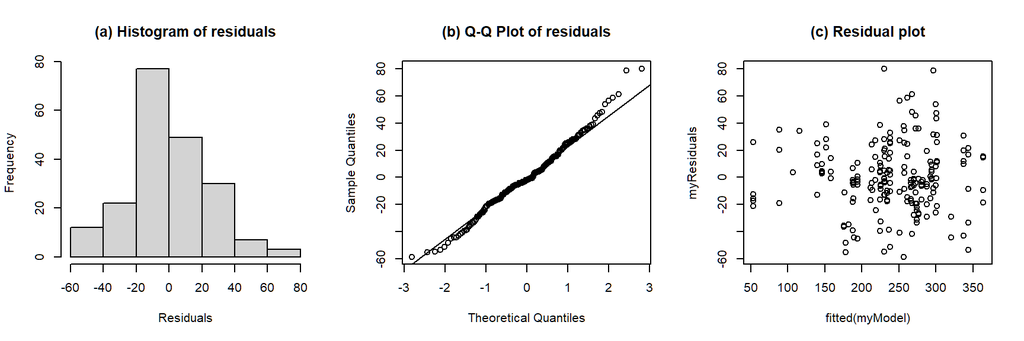

```
## Formula:  h_t ~ acc_phon + ana_syls + wrd_end_syl + gender + (1 | speaker)
##
## Linear mixed model fit by REML. t-tests use Satterthwaite's method [
## lmerModLmerTest]
## Formula: h_t_orig_equation
##    Data: pn_h_data_orig.trimmed
## Control:
## lmerControl(optimizer = optimizer, calc.derivs = FALSE, optCtrl = list(method = "nlminb",
##     starttests = FALSE, kkt = FALSE))
##
## REML criterion at convergence: 1847.8
##
## Scaled residuals:
##      Min       1Q   Median       3Q      Max
## -2.24847 -0.59653 -0.07416  0.58131  3.07462
##
## Random effects:
##  Groups   Name        Variance Std.Dev.
##  speaker  (Intercept) 729.0    27.00
##  Residual             675.2    25.98
## Number of obs: 200, groups:  speaker, 11
##
## Fixed effects:
##              Estimate Std. Error      df t value Pr(>|t|)
## (Intercept)   308.768     17.395  45.010  17.750  < 2e-16 ***
## acc_phon>H*   -36.116      8.577 190.680  -4.211 3.92e-05 ***
## acc_phonH*    -86.749     11.518 189.733  -7.531 1.99e-12 ***
## ana_syls1     -61.168     13.988 184.905  -4.373 2.04e-05 ***
## ana_syls2     -25.018     13.411 185.015  -1.865  0.06370 .
## ana_syls3     -18.751     13.637 185.108  -1.375  0.17078
## wrd_end_syl3    1.301     12.956 185.748   0.100  0.92012
## genderM       -77.646     16.927   9.209  -4.587  0.00124 **
## ---
## Signif. codes:  0 '***' 0.001 '**' 0.01 '*' 0.05 '.' 0.1 ' ' 1
##
## Correlation of Fixed Effects:
##             (Intr) ac_>H* acc_H* an_sy1 an_sy2 an_sy3 wrd__3
## acc_phon>H* -0.039
## acc_phonH*  -0.050  0.361
## ana_syls1   -0.739  0.006 -0.035
```

[output cut: 15 more lines]

```
## Backward reduced fixed-effect table:
## Degrees of freedom method: Satterthwaite
##
##             Eliminated Sum Sq Mean Sq NumDF   DenDF F value    Pr(>F)
## wrd_end_syl          1      7     6.8     1 185.748  0.0101  0.920121
## acc_phon             0  40292 20146.1     2 189.393 29.9973 4.817e-12 ***
## ana_syls             0  84705 28235.1     3 184.780 42.0417 < 2.2e-16 ***
## gender               0  14140 14139.7     1   9.193 21.0539  0.001242 **
## ---
## Signif. codes:  0 '***' 0.001 '**' 0.01 '*' 0.05 '.' 0.1 ' ' 1
##
## Model found:
## h_t ~ acc_phon + ana_syls + gender + (1 | speaker)
##
## isSingular(my_model, tol = 1e-05 ) --> FALSE
```

ANOVA of model: h_t ~ acc_phon + ana_syls + wrd_end_syl + gender + (1 | speaker)

| term | sumsq | meansq | NumDF | DenDF | F value | p.value | p.adj (BH) | signif. |
| --- | --- | --- | --- | --- | --- | --- | --- | --- |
| acc_phon | 40034 | 20017 | 2 | 188.44 | 29.65 | <.001 | <.001 | p<.001 |
| ana_syls | 49662 | 16554 | 3 | 184.22 | 24.52 | <.001 | <.001 | p<.001 |
| wrd_end_syl | 6.81 | 6.81 | 1 | 185.75 | 0.01 | .920 | .966 |  |
| gender | 14208 | 14208 | 1 | 9.21 | 21.04 | .001 | .006 | p<.01 |

Conditional and marginal R<sup>2</sup> of model

| R2_conditional | R2_marginal |
| --- | --- |
| 0.86 | 0.7 |

$acc_phon

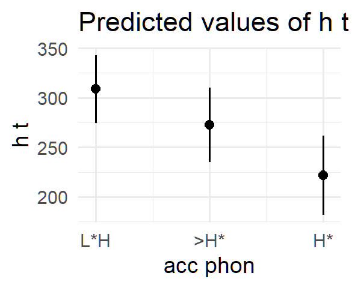

$ana_syls

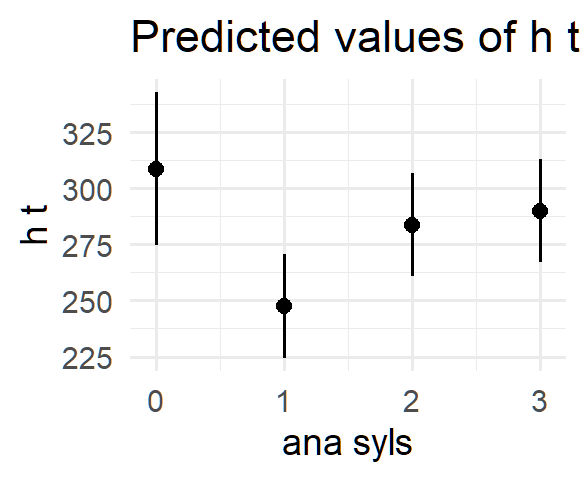

$wrd_end_syl

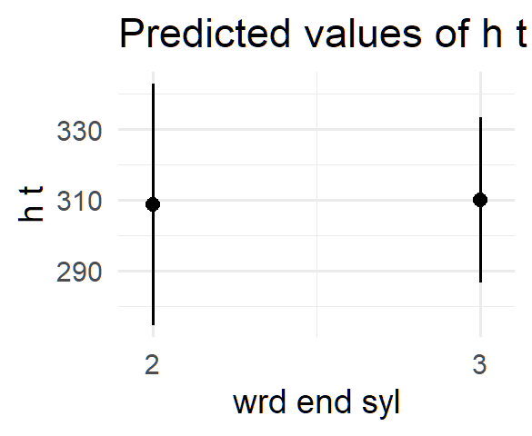

$gender

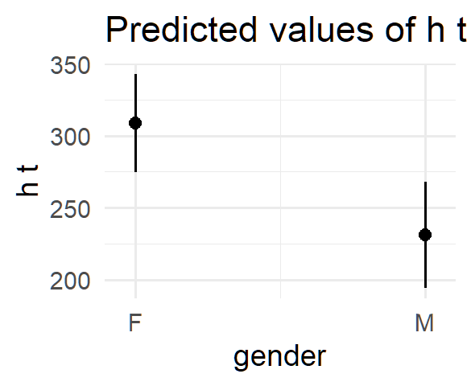

summary of model: h_t ~ acc_phon + ana_syls + wrd_end_syl + gender + (1 | speaker)

| term | estimate | conf.low | conf.high | std.error | t.value | df | p.value |
| --- | --- | --- | --- | --- | --- | --- | --- |
| (Intercept) | 308.768 | 273.73212 | 343.803477 | 17.395 | 17.750 | 45.01 | 6.0e-22 |
| acc_phon>H* | -36.116 | -53.03437 | -19.197779 | 8.577 | -4.211 | 190.68 | 3.9e-05 |
| acc_phonH* | -86.749 | -109.46961 | -64.028439 | 11.518 | -7.531 | 189.73 | 2.0e-12 |
| ana_syls1 | -61.168 | -88.76531 | -33.570960 | 13.988 | -4.373 | 184.91 | 2.0e-05 |
| ana_syls2 | -25.018 | -51.47517 | 1.439996 | 13.411 | -1.865 | 185.02 | 0.0637 |
| ana_syls3 | -18.751 | -45.65381 | 8.152263 | 13.637 | -1.375 | 185.11 | 0.1708 |
| wrd_end_syl3 | 1.301 | -24.25813 | 26.860100 | 12.956 | 0.100 | 185.75 | 0.9201 |
| genderM | -77.646 | -115.80506 | -39.487543 | 16.927 | -4.587 | 9.21 | 0.0012 |

b0 for h_t ~ acc_phon + ana_syls + wrd_end_syl + gender + (1 | speaker) [using original model]

| intercept | estimate | conf.low | conf.high | std.error | t.value | df | p.value |
| --- | --- | --- | --- | --- | --- | --- | --- |
| acc_phonL*H | 308.8 | 273.7 | 343.8 | 17.40 | 17.75 | 45.01 | 6.0e-22 |
| acc_phon>H* | 272.6 | 234.4 | 310.9 | 19.10 | 14.28 | 59.40 | 7.3e-21 |
| acc_phonH* | 222 | 181.4 | 262.6 | 20.38 | 10.89 | 72.64 | 6.2e-17 |
| ana_syls0 | 308.8 | 273.7 | 343.8 | 17.40 | 17.75 | 45.01 | 6.0e-22 |
| ana_syls1 | 247.6 | 221.5 | 273.7 | 11.77 | 21.03 | 10.44 | 7.0e-10 |
| ana_syls2 | 283.8 | 257.7 | 309.8 | 11.71 | 24.23 | 10.22 | 2.3e-10 |
| ana_syls3 | 290 | 264 | 316.1 | 11.73 | 24.72 | 10.30 | 1.7e-10 |

b1 for h_t ~ acc_phon + ana_syls + wrd_end_syl + gender + (1 | speaker) [using original model]

| intercept | slope | estimate | conf.low | conf.high | std.error | t.value | df | p.value |
| --- | --- | --- | --- | --- | --- | --- | --- | --- |
| acc_phonL*H | acc_phon>H* | -36.1 | -53 | -19.2 | 8.580 | -4.210 | 190.68 | 3.9e-05 |
| acc_phonL*H | acc_phonH* | -86.8 | -109.5 | -64 | 11.520 | -7.530 | 189.73 | 2.0e-12 |
| acc_phon>H* | acc_phonH* | -50.6 | -73.6 | -27.7 | 11.620 | -4.360 | 184.30 | 2.2e-05 |
| ana_syls0 | ana_syls1 | -61.2 | -88.8 | -33.6 | 13.990 | -4.370 | 184.91 | 2.0e-05 |
| ana_syls0 | ana_syls2 | -25 | -51.5 | 1.44 | 13.410 | -1.870 | 185.02 | 0.064 |
| ana_syls0 | ana_syls3 | -18.8 | -45.7 | 8.152 | 13.640 | -1.380 | 185.11 | 0.171 |
| ana_syls1 | ana_syls2 | 36.1 | 25.6 | 46.7 | 5.330 | 6.780 | 184.18 | 1.6e-10 |
| ana_syls1 | ana_syls3 | 42.4 | 31.8 | 53.1 | 5.400 | 7.850 | 184.23 | 3.2e-13 |
| ana_syls2 | ana_syls3 | 6.27 | -3.63 | 16.2 | 5.020 | 1.250 | 183.05 | 0.213 |
| intercept | wrd_end_syl3 | 1.301 | -24.3 | 26.9 | 12.956 | 0.100 | 185.75 | 0.92 |
| intercept | genderM | -77.6 | -115.8 | -39.5 | 16.927 | -4.587 | 9.21 | 0.001 |